# Matemáticas para investigadores nivel Dos

### **Capítulo 6**

- Talleres de evaluación.

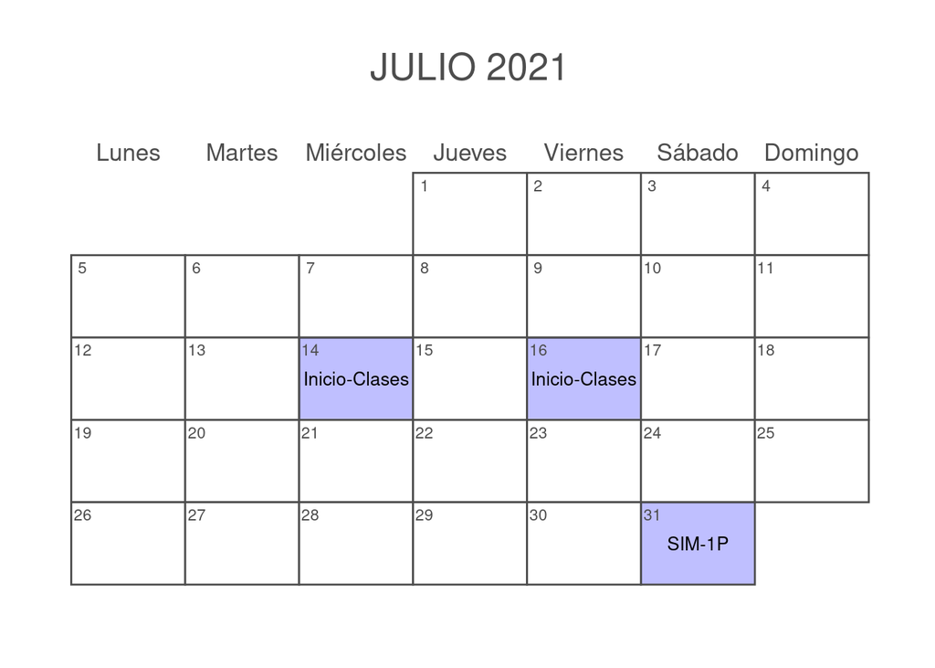

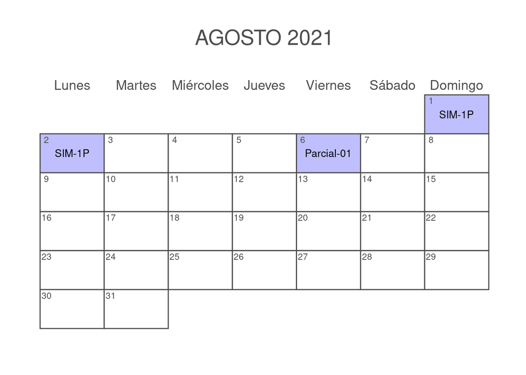

# Bibliografía

- Samuels, M., Witmer, J., & Schaffner, A. (2012). Statistics for the life sciences (4 ed.). Boston: Pearson Education.
- Milton, J. S. (2001). Estadística para la biología y ciencias de la salud (3 ed.). Madrid: McGraw- Hill/Interamericana.
- Daniel, W. W. 2004. Bioestadística. Base para el análisis de las ciencias de la salud. 4era. Ed. Limusa Wiley Noriega Editores. México.
- Johnson, R. A. & Bhattacharyya, G. K. (2010). Statistics. Principles and Methods (6 ed.). New York: John Wiley and Sons, Inc
- Zar, J. (1999). Biostatistical analysis (5 ed.). Prentice hall Upper Saddle River, NJ.
- Zuur, A., Ieno, E., & Meesters, E. (2009). A Beginner’s Guide to R. Springer.
- Uribe Calad Julio Alberto. Matemáticas básicas y operativas: primer semestre de universidad. Medellín [Colombia]: Ed. Susaeta1986. páginas:639
- Silva, Luis Carlos. Cultura estadística e investigación científica en el campo de la salud: una mirada crítica. Editorial Díaz de Santos 1997.
- Louis Leithod, El Cálculo, Ed Oxford University Press 1998, 7° edición
- Zill D. Ecuaciones diferenciales con aplicaciones de modelado. International Thomson Editores. 6 Edición